# Good Plot/Bad Plot

Cameron Atighetchi

2023-04-07

# Good Plot / Bad Plot

## Loading Libraries

```r
library(prettydoc)
library(tidyverse)
library(here)
library(ggthemes)
library(patchwork)
library(ggrepel)
```

## Loading and Explaining Data

For this project I decided to use a dataset containing the best selling musical artists per year and genre based on Total Certifiable Units

```r
artists <- read_csv(here("Good_Plot_Bad_Plot", "Data","artists.csv"))
```

This dataset includes 7 columns:

- ‘Artist’ : Name of the artist
- ‘Country’ : Country from where the artist is from
- ‘period_active’ : Time when the artists made their music
- ‘Year’ : Release year of their first chartered record
- ‘Genre’ : Genre of the artist’s music
- ‘TCU’ : Total Certified Units
- ‘Sales’ : Claimed sales of the records

## Bad Plot

Using Claus Wilke’s and Healy’s guidelines my *bad plot* is considered bad because of the **misuse** of:

- **Color Scheme**: Here we see a very contrasting color scheme that only works to confuse the audience and make the plot harder to read
- **Bad Use of Data**: The data used on the y axis is not a quantitative value and is reflected in all the legend values
- **Visualization of Axes**: The axes are bundled up and crammed together and very misleading
- **Perceptual Misinterpretations**: No titles or captions to explain what the plot is showing and can be perceived wrong
- **Gestalt Rules**: No continuity, connection, or similarity within the legend, axes, and point aspects of the plot
- **Difficulty of reading**: No distinction between the different colored points in the plot
- **Ugly**: The color scheme, point colors, and theme do not mesh together at all

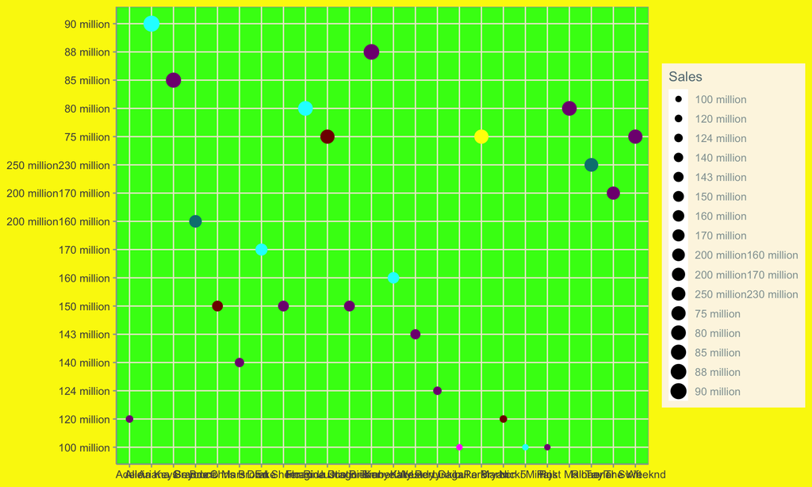

```r
artists2 <- read_csv(here("Good_Plot_Bad_Plot", "Data","artists.csv"))
artists2 %>%
  filter(Year >= 1990) %>%
  ggplot(aes(x = Artist, y = Sales, size = Sales, color = Genre)) +
  geom_point() +
  theme_solarized() +
  theme(panel.background = element_rect(fill = "#39ff14"),
        plot.background = element_rect(fill = "#faf607"),
        axis.title = element_blank()) +
  scale_color_excel() +
  guides(color = FALSE)
```

## Step #1 : Now we should start to filter and create a simple plot of TCU for each Artist

```r
artistplot <- artists %>%
  filter(Year >= 2000) %>%  #only show values greater than or equal to the year 2000
  ggplot(aes(x = Artist, y = TCU, alpha = 0.5, label = Artist)) + # create a ggplot with aesthetics and transparent points
  geom_label_repel(force = 0.2, nudge_y = 0.5, force_pull = 0.2, size = 2.5, segment.color = "white") + # create labels for each artist
  geom_point(aes(size = TCU, color = Genre)) + # create points with varying size based on TCU and color based on genre
  theme_minimal() +
  scale_color_brewer() +
  theme(panel.grid.minor = element_line(linetype = "dashed", # gives a dashed line to the the minor gridlines
                                    color = "gray"),
    panel.grid.major = element_blank(), # gets rid of major grid lines
    axis.ticks = element_blank(), # gets rid of axis ticks in both axes
    axis.line = element_line(linewidth = .5, color = "gray"), #gives the x axis a line
    axis.text.x = element_blank(), # gets rid of text on x axis
    axis.text.y = element_text(color = "gray"), # turns text on y axis gray
    axis.title.x = element_blank(),# gets rid of axis title
    plot.background = element_rect(fill = "#1f313d"), # turns plot background to navy blue
    text = element_text(color = "gray"), # turns all text gray
    legend.background = element_rect(color = "gray", size = .4, fill = NA)) + # gives legends a border
    labs(size = "TCU (millions)", y = "Total Certifiable Units (millions)") + # changes legend title
    guides(alpha = FALSE) # gets rid of an extra title
```

## Step #2 : I also want to include a smaller version of the first plot faceted by genre

```r
genreplot <- artists %>%
  filter(Year >= 2000) %>% #only show values greater than or equal to the year 2000
  ggplot(aes(x = Artist, y = TCU, alpha = 0.5)) + # create a ggplot with aesthetics and transparent points
  geom_point(aes(size = TCU, color = Genre)) + # create points with varying size based on TCU and color based on genre
  facet_wrap(~Genre) + # facet wrap based on genre
  theme_minimal() +
  scale_color_brewer() +
  theme(panel.grid.minor = element_line(linetype = "dashed", # gives a dashed line to the the minor gridlines
                                    color = "gray"),
    panel.grid.major = element_blank(), # gets rid of major grid lines
    axis.line = element_line(linewidth = .5, color = "gray"),  #gives the x axis a line
    axis.ticks = element_blank(), # gets rid of axis ticks in both axes
    axis.title = element_blank(),  # gets rid of axis title
    axis.text.x = element_blank(), # gets rid of text on x axis
    panel.border = element_rect(color = "gray", fill = NA),
    plot.background = element_rect(fill = "#1f313d"), # turns plot background to navy blue
    text = element_text(color = "gray"), # turns all text gray
    strip.text = element_text(color = "gray"), # turns all faceted plot titles gray
    axis.text.y = element_text(color = "gray")) + # turns y axis text gray
  guides(color = FALSE, size = FALSE, alpha = FALSE) # gets rid of all legends
```

## Final Step: Combine these two plots using patchwork

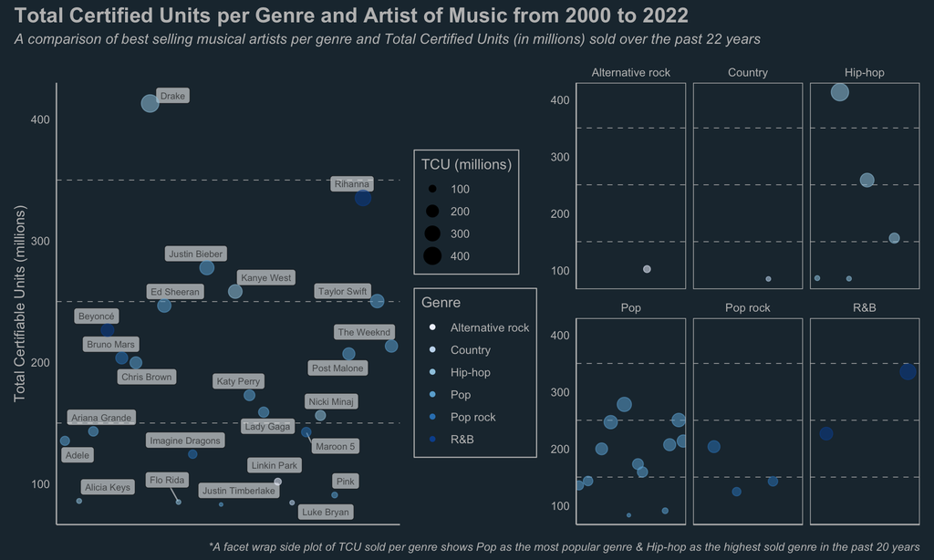

```r
(artistplot + genreplot)  + # joins together both plots
  plot_annotation(title = "Total Certified Units per Genre and Artist of Music from 2000 to 2022",
                  subtitle = "A comparison of best selling musical artists per genre and Total Certified Units (in millions) sold over the past 22 years",
                  caption = "*A facet wrap side plot of TCU sold per genre shows Pop as the most popular genre & Hip-hop as the highest sold genre in the past 20 years") &
  theme(plot.background = element_rect(fill = "#1f313d", color = NA), # changes plot background
                                       plot.title.position = "plot", # brings title into plot
        plot.title = element_text(color = "gray", size = 16, face = "bold"), # bold title
        plot.subtitle = element_text(color = "gray", face = "italic"), # italics for subtitle
        plot.caption = element_text(color = 'gray', face = "italic")) # italics for caption
```